# Time sync check

```
[1] "data/2019 BAR recordings/NNS DOC Station nests/NNS1/NNS1_20191203_STUDY [-39.0986 176.8061]/NNS1_20191203_064040_SunriseToSunset [-39.0986 176.8061].wav 43824.3009169214 18528754 18616403"
[1] "data/2019 BAR recordings/NNS DOC Station nests/NNS1/NNS1_20191203_STUDY [-39.0986 176.8061]/NNS1_20191203_064040_SunriseToSunset [-39.0986 176.8061].wav 43824.3009169214 35751704 35839353"
```

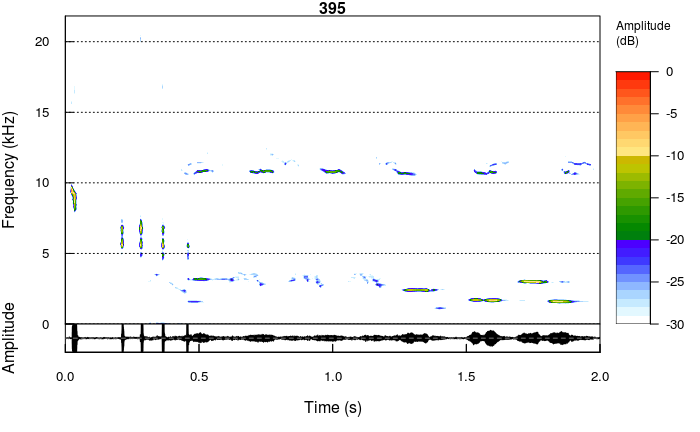

```
[1] "data/2019 BAR recordings/NNS DOC Station nests/NNS1/NNS1_20191203_STUDY [-39.0986 176.8061]/NNS1_20191203_064040_SunriseToSunset [-39.0986 176.8061].wav 43824.3009169214 53193776 53281425"
```

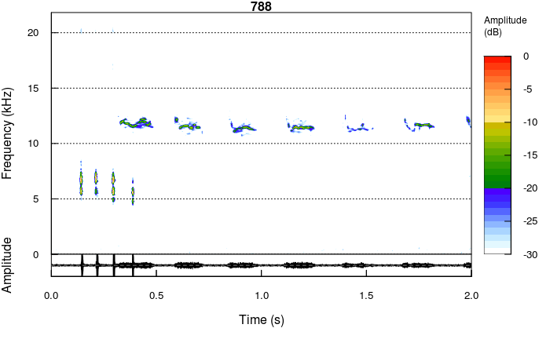

```
[1] "data/2019 BAR recordings/NNS DOC Station nests/NNS1/NNS1_20191203_STUDY [-39.0986 176.8061]/NNS1_20191203_064040_SunriseToSunset [-39.0986 176.8061].wav 43824.3009169214 71074091 71161740"
```

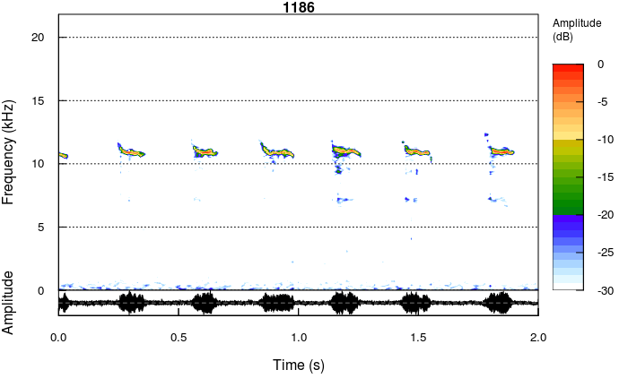

```
[1] "data/2019 BAR recordings/NNS DOC Station nests/NNS1/NNS1_20191203_STUDY [-39.0986 176.8061]/NNS1_20191203_064040_SunriseToSunset [-39.0986 176.8061].wav 43824.3009169214 89129703 89217352"
```

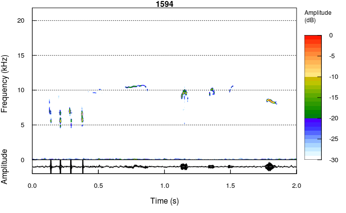

```
[1] "data/2019 BAR recordings/NNS DOC Station nests/NNS1/NNS1_20191203_STUDY [-39.0986 176.8061]/NNS1_20191203_064040_SunriseToSunset [-39.0986 176.8061].wav 43824.3009169214 106527950 106615599"
```

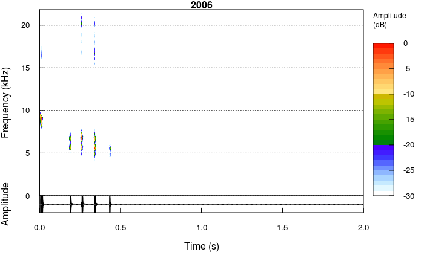

```
[1] "data/2019 BAR recordings/NNS DOC Station nests/NNS1/NNS1_20191203_STUDY [-39.0986 176.8061]/NNS1_20191203_064040_SunriseToSunset [-39.0986 176.8061].wav 43824.3009169214 144961862 145049511"
```

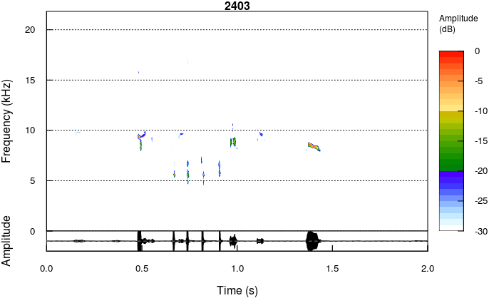

```
[1] "data/2019 BAR recordings/NNS DOC Station nests/NNS1/NNS1_20191203_STUDY [-39.0986 176.8061]/NNS1_20191203_064040_SunriseToSunset [-39.0986 176.8061].wav 43824.3009169214 162579231 162666880"
```

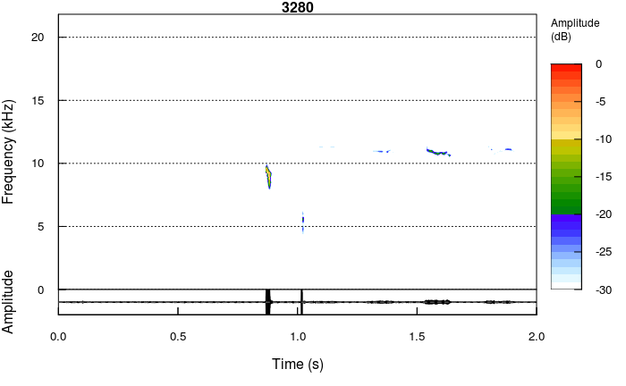

```
[1] "data/2019 BAR recordings/NNS DOC Station nests/NNS1/NNS1_20191203_STUDY [-39.0986 176.8061]/NNS1_20191203_064040_SunriseToSunset [-39.0986 176.8061].wav 43824.3009169214 179714533 179802182"
```

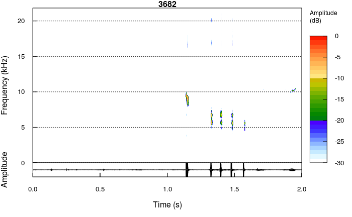

```
[1] "data/2019 BAR recordings/NNS DOC Station nests/NNS1/NNS1_20191203_STUDY [-39.0986 176.8061]/NNS1_20191203_064040_SunriseToSunset [-39.0986 176.8061].wav 43824.3009169214 197375726 197463375"
```

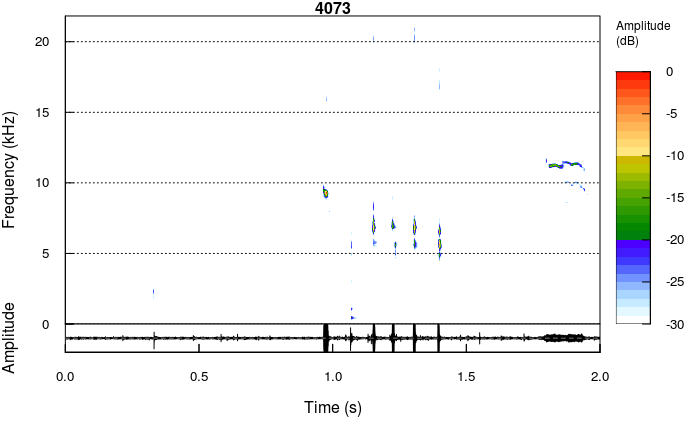

```
[1] "data/2019 BAR recordings/NNS DOC Station nests/NNS1/NNS1_20191203_STUDY [-39.0986 176.8061]/NNS1_20191203_064040_SunriseToSunset [-39.0986 176.8061].wav 43824.3009169214 215518987 215606636"
```

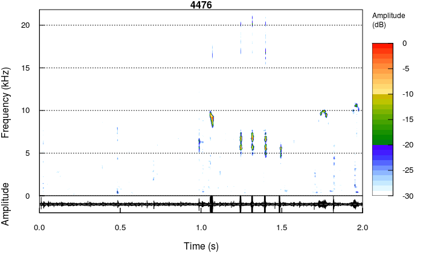

```
[1] "data/2019 BAR recordings/NNS DOC Station nests/NNS1/NNS1_20191203_STUDY [-39.0986 176.8061]/NNS1_20191203_064040_SunriseToSunset [-39.0986 176.8061].wav 43824.3009169214 232566640 232654289"
```

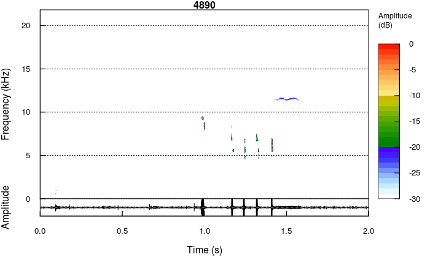

```
[1] "data/2019 BAR recordings/NNS DOC Station nests/NNS1/NNS1_20191203_STUDY [-39.0986 176.8061]/NNS1_20191203_064040_SunriseToSunset [-39.0986 176.8061].wav 43824.3009169214 270781430 270869079"
```

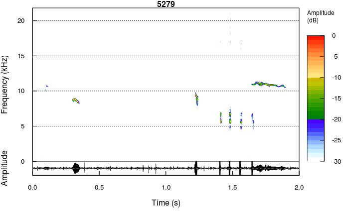

```
[1] "data/2019 BAR recordings/NNS DOC Station nests/NNS1/NNS1_20191203_STUDY [-39.0986 176.8061]/NNS1_20191203_064040_SunriseToSunset [-39.0986 176.8061].wav 43824.3009169214 288092029 288179678"
```

[3 more figures not shown]

```r
f = "NNS1_20191203_064040_SunriseToSunset [-39.0986 176.8061].wav"
offset = median(annotations$offset[annotations$filename == f], na.rm=TRUE) # offset for this file
matched_df = df[df$base_filename == f,]
matched_event_offsets = time_length(rfid$datetime[rfid$msg == "PB0023.wav" & rfid$datetime %within% matched_df$interval & rfid$site == matched_df$site] - matched_df$start)
for (begin_time in matched_event_offsets) {
  sr = matched_df$true_sr
  clip_start = round((begin_time + offset) * sr)
  clip_end = round(clip_start + (sr * 2))
  print(paste(matched_df$filename, matched_df$true_sr, clip_start, clip_end))
  wav = readWave(filename = matched_df$filename, from = clip_start, to = clip_end, units="samples")
  wav@samp.rate = sr
  spectro(wav, main=begin_time, osc=TRUE)
  #play(wav)
}
```

Not bad.

## Let’s rename these RFID codes with something a bit more readable. We’ll need to maintain a way of converting between.

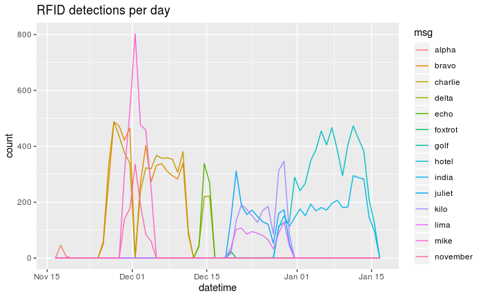

```r
unique_rfids = unique(rfid$msg[str_extract(rfid$msg, "^.{2}") == "RF"])
#human_readable_rfids = paste0("bird", 1:length(unique_rfids))
human_readable_rfids = c("alpha", "bravo", "charlie", "delta", "echo", "foxtrot", "golf", "hotel", "india", "juliet", "kilo", "lima", "mike", "november")
human_readable_rfids = setNames(human_readable_rfids, unique_rfids)
unique_rfids = setNames(unique_rfids, human_readable_rfids)

processed_rfid = rfid
mask = str_extract(processed_rfid$msg, "^.{2}") == "RF"
processed_rfid$msg[mask] = human_readable_rfids[processed_rfid$msg[mask]]
ggplot(processed_rfid[mask,], aes(x = datetime, color = msg)) +
  geom_freqpoly(binwidth = 60 * 60 * 24) +
  ggtitle("RFID detections per day")
```

## Try detect entry / exit events by looking at light gate changes

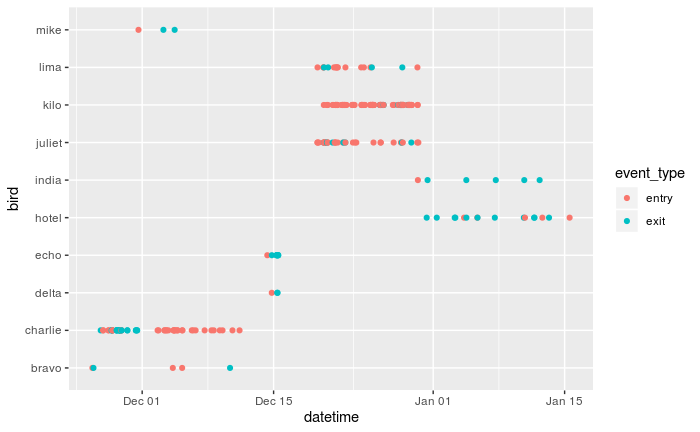

```r
if (file.exists("misc/processed_rfid.csv")) {
  processed_rfid2 = read.csv("misc/processed_rfid.csv")
  processed_rfid2$datetime = ymd_hms(processed_rfid2$datetime)
} else {
  time_threshold = 2
  LG_threshold = 1
  processed_rfid2 = pblapply(1:sum(mask), function(i) {
    dt = processed_rfid$datetime[mask][i]
    this_site = processed_rfid$site[mask][i]
    bird = processed_rfid$msg[mask][i]
    LG = filter(processed_rfid, site == this_site & abs(datetime - dt) < time_threshold & msg == "Light Gate Change")
    if (nrow(LG) > 2) {
      event_type = NULL
      ext_g = mean(diff(LG$ext))
      int_g = mean(diff(LG$int))
      if (ext_g < 0 & int_g > 0) {
        event_type = "entry"
      } else if (int_g < 0 & ext_g > 0) {
        event_type = "exit"
      }
      if (length(event_type) == 1) {
        print(paste(i, bird, event_type, this_site, dt))
        return(data.frame(i = i, bird = bird, event_type = event_type, ext_g = ext_g, int_g = int_g, site = this_site, datetime = dt))
      }
    }
  })
  processed_rfid2 = do.call(rbind, processed_rfid)
  write.csv(processed_rfid2, "misc/processed_rfid.csv", row.names=FALSE)
}
ggplot(processed_rfid2, aes(x = datetime, y = bird, color = event_type)) + geom_point()
```

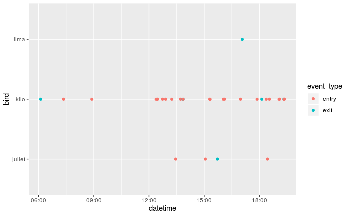

```r
ggplot(filter(processed_rfid2, datetime > ymd("2019-12-28") & datetime < ymd("2019-12-29")), aes(x = datetime, y = bird, color = event_type)) + geom_point()
```

Seems a bit too unreliable - the light gates might be too sensitive. Looks like we’ll have to just slice around RFID passes.

## Build a dataframe of datetime intervals to slice - intelligently overlapping for same bird id, and removing intervals where there might be confusion (a playback, or another bird)

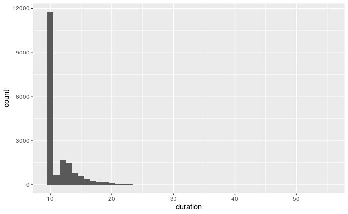

```r
time_threshold = 5
events_to_ignore = c("Power-on Reset", "Low-voltage Detect Reset", "Light Gate Change",
  "Watchdog(COP) Reset", "Playback Error! Restarting", "Software Reset"
)

if (file.exists("misc/dts_to_slice_deduplicated.csv")) {
  dts_to_slice_deduplicated = read.csv("misc/dts_to_slice_deduplicated.csv")
  dts_to_slice_deduplicated$start = ymd_hms(dts_to_slice_deduplicated$start)
  dts_to_slice_deduplicated$end = ymd_hms(dts_to_slice_deduplicated$end)
} else {
  dts_to_slice = pblapply(1:sum(mask), function(i) {
      dt = processed_rfid$datetime[mask][i]
      this_site = processed_rfid$site[mask][i]
      bird = processed_rfid$msg[mask][i]
      this_id = processed_rfid$id[mask][i]

      start = dt - time_threshold
      end = dt + time_threshold
      nearby_events = filter(processed_rfid, id != this_id & site == this_site & abs(time_length(datetime - dt)) < time_threshold & !(msg %in% events_to_ignore))
      other_birds = human_readable_rfids[!human_readable_rfids == bird]
      if (any(other_birds %in% nearby_events$msg)) {
        print(paste(i, "another bird within threshold"))
        return(NULL)
      }
      if (any(str_extract(nearby_events$msg, "^.{2}") == "PB")) {
        print(paste(i, "playback within threshold"))
        return(NULL)
      }
      data.frame(i = i, site = this_site, bird = bird, start = start, end = end, interval = interval(start, end))
  })
  dts_to_slice = do.call(rbind, dts_to_slice)
  write.csv(dts_to_slice, "misc/dts_to_slice.csv", row.names = FALSE)

  dts_to_slice_deduplicated = dts_to_slice %>% group_by(site, bird) %>% arrange(start) %>%
                        mutate(indx = c(0, cumsum(as.numeric(lead(start)) >
                                cummax(as.numeric(end)))[-n()])) %>%
                        group_by(site, bird, indx) %>%
                        summarise(start = min(start), end = max(end)) %>%
                        select(-indx)
  dts_to_slice_deduplicated$duration = time_length(dts_to_slice_deduplicated$end - dts_to_slice_deduplicated$start)
  write.csv(dts_to_slice_deduplicated, "misc/dts_to_slice_deduplicated.csv", row.names = FALSE)
}
ggplot(dts_to_slice_deduplicated, aes(duration)) + geom_histogram(binwidth = 1)
```

## Put median offset per file in df

## For each interval around a RFID pass, output a wave clip, corrected for offset and SR

```r
df$offset = sapply(df$base_filename, function(f) {
  median(annotations$offset[paste0(annotations$filename) == f], na.rm = TRUE)
})
invisible(pblapply(1:nrow(dts_to_slice_deduplicated), function(i) {
  start = dts_to_slice_deduplicated$start[i]
  duration = dts_to_slice_deduplicated$duration[i]
  bird = dts_to_slice_deduplicated$bird[i]
  site = dts_to_slice_deduplicated$site[i]
  formatted_date = format(start, "%Y-%m-%d_%H%M%S_NZDT")
  output_filename = paste0("data/2019 BAR recordings - individual bird clips/", bird, "/", site, "_", formatted_date, ".wav")
  if (file.exists(output_filename)) {
    return(NULL)
  }
  matched_df = df[df$site == site & start %within% df$interval & !is.na(df$offset) & !is.na(df$true_sr),]
  if (nrow(matched_df) == 1) {
    sr = matched_df$true_sr
    clip_start_s = time_length(start - matched_df$start) + matched_df$offset
    clip_start_samples = round(clip_start_s * sr)
    clip_end_samples = round(clip_start_samples + (sr * duration))
    #print(paste(i, bird, site, start, duration, matched_df$filename, matched_df$true_sr, clip_start_samples, clip_end_samples))
    try({
      wav = readWave(filename = matched_df$filename, from = clip_start_samples, to = clip_end_samples, units="samples")
      wav@samp.rate = sr
      if (sr != 44100) {
        wav = resamp(wav, g = 44100, output = "Wave")
      }
      wav@left = round(wav@left)
      mkdirs(dirname(output_filename))
      writeWave(wav, filename = output_filename, extensible = F)
    })
  }
}))
```

[output not shown]

[output not shown]

[output not shown]

[output not shown]

[output not shown]

[output not shown]

```
  |+++++++++++++++++++++                             | 42% ~43s
```

```
Error in readBin(con, int, n = N, size = bytes, signed = (bytes != 1),  :
  invalid 'n' argument
```

```
  |++++++++++++++++++++++                            | 43% ~43s
```

[output not shown]

[output not shown]

[output not shown]

```
  |++++++++++++++++++++++++++                        | 51% ~36s
```

[output not shown]

```
  |++++++++++++++++++++++++++                        | 52% ~36s
```

[output not shown]

```
  |+++++++++++++++++++++++++++                       | 53% ~35s
```

[output not shown]

```
  |+++++++++++++++++++++++++++                       | 54% ~35s
  |++++++++++++++++++++++++++++                      | 55% ~34s
  |++++++++++++++++++++++++++++                      | 56% ~33s
```

```
Error in readBin(con, int, n = N, size = bytes, signed = (bytes != 1),  :
  invalid 'n' argument
```

```
  |+++++++++++++++++++++++++++++                     | 57% ~32s
```

```
Error in readBin(con, int, n = N, size = bytes, signed = (bytes != 1),  :
  invalid 'n' argument
```

```
  |+++++++++++++++++++++++++++++                     | 58% ~32s
  |++++++++++++++++++++++++++++++                    | 59% ~31s
```

[output not shown]

```
  |++++++++++++++++++++++++++++++                    | 60% ~30s
```

[output not shown]

[output not shown]

```
Error in readBin(con, int, n = N, size = bytes, signed = (bytes != 1),  :
  invalid 'n' argument
```

```
  |+++++++++++++++++++++++++++++++++                 | 65% ~26s
```

```
Error in readBin(con, int, n = N, size = bytes, signed = (bytes != 1),  :
  invalid 'n' argument
```

```
  |+++++++++++++++++++++++++++++++++                 | 66% ~26s
```

```
Error in readBin(con, int, n = N, size = bytes, signed = (bytes != 1),  :
  invalid 'n' argument
```

[output not shown]

```
Error in readBin(con, int, n = N, size = bytes, signed = (bytes != 1),  :
  invalid 'n' argument
```

[output not shown]

```
Error in readBin(con, int, n = N, size = bytes, signed = (bytes != 1),  :
  invalid 'n' argument
```

```
  |++++++++++++++++++++++++++++++++++++++++          | 79% ~16s
  |++++++++++++++++++++++++++++++++++++++++          | 80% ~15s
  |+++++++++++++++++++++++++++++++++++++++++         | 81% ~14s
```

```
Error in readBin(con, int, n = N, size = bytes, signed = (bytes != 1),  :
  invalid 'n' argument
```

[output not shown]

```
Error in readBin(con, int, n = N, size = bytes, signed = (bytes != 1),  :
  invalid 'n' argument
```

```
  |+++++++++++++++++++++++++++++++++++++++++++++     | 89% ~08s
  |+++++++++++++++++++++++++++++++++++++++++++++     | 90% ~08s
  |++++++++++++++++++++++++++++++++++++++++++++++    | 91% ~07s
  |++++++++++++++++++++++++++++++++++++++++++++++    | 92% ~06s
```

```
Error in readBin(con, int, n = N, size = bytes, signed = (bytes != 1),  :
  invalid 'n' argument
```

[output not shown]

## Use monitoR to remove silence in sliced clips

```r
files = list.files("data/Sound templates", pattern = "*.txt$", full.names=TRUE)
f = files[1]
selection_table = read.table(f, header=TRUE, sep="\t")
freq_lim = c(selection_table$Low.Freq..Hz., selection_table$High.Freq..Hz.)/1000
wave_filename = str_replace(f, ".Table.1.selections.txt", ".wav")
template_id = substr(basename(f), 1, 8)
template_wav = readWave(wave_filename, from = selection_table$Begin.Time..s., to = selection_table$End.Time..s., units="seconds")
template_wav = resamp(template_wav, g = 44100, output = "Wave")
template_duration = length(template_wav@left) / 44100
processed_template_wave_filename = paste0("misc/", basename(wave_filename))
savewav(template_wav, filename = processed_template_wave_filename)
ctemps = makeCorTemplate(processed_template_wave_filename, wl = 300, frq.lim = freq_lim, name = template_id)
```

```
Automatic point selection.

Done.
```

```r
templateCutoff(ctemps) = c(default=.5)

buffer = 0

for (bird in human_readable_rfids) {
  files_for_bird = Sys.glob(paste0("data/2019 BAR recordings - individual bird clips/", bird, "/*.wav"))
  clips = c()
  if (length(files_for_bird) == 0) {
    next
  }
  for (i in 1:length(files_for_bird)) {
    f = files_for_bird[i]
    cscores = corMatch(f, ctemps, quiet=TRUE)
    cdetects = findPeaks(cscores)
    detects = getDetections(cdetects)
    if (i == 1) {
      plot(cdetects)
    }
    if (nrow(detects) > 1) {
      for (j in 1:nrow(detects)) {
        start_time = detects$time[j]
        clip = readWave(f, from = start_time - buffer, to = start_time + template_duration + buffer, units = "seconds")@left
        clips = c(clips, clip)
      }
    }
  }
  if (length(clips) > 10) {
    wav = Wave(clips, samp.rate = 44100, bit = 16)
    output_filename = paste0("data/2019 BAR recordings - individual bird clips/", bird, ".wav")
    writeWave(wav, output_filename, extensible = F)
  }
}
```

```
Done with  ZOOM0003
Done
```

```
0 to 10.000022675737 seconds
```

[output not shown]

[output cut: 4567 more lines]

[output not shown]